# Mineração de Dados Geoespaciais - Anexo I

Fernando Ferraz Ribeiro

Beth Leite Soares

O objetivo deste notebook é juntar dados de um shapefile com um mapa do Open Street Maps(OSM)

## Testando o ambiente de trabalho (conda environment)

Mostrando o caminho que o servidor Jupyter carrega o interpretador Python (python.exe) e carregas o anbiente (\envs)

```python
import os
import sys
print(sys.executable)
pathFix = sys.prefix
print(pathFix)
```

```
C:\Users\ffrib\AppData\Local\conda\conda\envs\Geodata_2018_12_08\python.exe
C:\Users\ffrib\AppData\Local\conda\conda\envs\Geodata_2018_12_08
```

## Lidando com erros do ambiente (WINDOWS ONLY)

Algumas bibliotecas importadas apresentam um erro apenas na plataforma Windows.

Caso esteja rodando no windows e tenha problemas com o sistema de coordenadas de referência (crs), rode a linha de comando abaixo:

```python
pathFix = pathFix .replace('\\', '/')
print(pathFix)
os.environ["PROJ_LIB"] =   pathFix + "/Library/share"
```

```
C:/Users/ffrib/AppData/Local/conda/conda/envs/Geodata_2018_12_08
```

mais informações no [Post sobre o Erro](https://github.com/geopandas/geopandas/issues/830)

## Importando Bibliotecas

```python
# Biblioteca basica de programação científica em python
import numpy as np
# biblioteca de análise de dados
import pandas as pd
# biblioteca de gráficos
import matplotlib.pyplot as plt
import matplotlib.cm as cm
import matplotlib.colors as colors
# Bibliotecas geopandas
import geopandas as gpd
# biblioteca de redes complexas
import networkx as nx
# biblioteca para acessar dados do Open sreet maps
import osmnx as ox
# ler dados remotamente da internet
```

```python
%matplotlib inline
ox.config(use_cache=True, log_console=True)
ox.__version__
```

```
'0.8.2'
```

## Criando coordenadas de recorte

```python
# coordenada inicial x
xSC = 555000
# variação da coordenada x
deltaX = 2000
# coordenada inicial y
ySC = 8570000
# variação da coordenada y
deltaY = 2000
```

## Limites da importaçâo

```python
from shapely.geometry import Polygon

recorte = gpd.GeoSeries([ Polygon([(xSC,ySC), (xSC + deltaX , ySC), (xSC + deltaX, ySC + deltaY ), (xSC, ySC + deltaY )]) ])
```

```python
# colocando em coordenaadas SIRGAS 2000
recorte.crs = {'proj': 'utm', 'zone': 24, 'south': True, 'ellps': 'aust_SA', 'units': 'm', 'no_defs': True}
```

## Carregando shapes

```python
# importando Shape dos bairros - polígonos
bairros = gpd.read_file('../shapefiles/BaseSSA/Limites/bairros_fim.shp', bbox = recorte )

# importando Shape das edificaçõs - polilinhas
edf = gpd.read_file('../shapefiles/BaseSSA/edificacoes_polyline.shp', bbox = recorte)

# importando shape de pontos
edf_pt = gpd.read_file('../shapefiles/BaseSSA/edificacoes_point.shp', bbox = recorte)
```

## Mostrando os dados dos shapes

### dados do shape bairros

```python
bairros.head()
```

|  | OBJECTID | BR_ | BR_ID | NM_BAIRROS | Shape_Leng | Shape_Area | geometry |
| --- | --- | --- | --- | --- | --- | --- | --- |
| 0 | 89 | 2 | 1 | Lobato | 10290.734146 | 1.508163e+06 | POLYGON ((556643.6323074758 8573040.904571733,... |
| 1 | 91 | 2 | 1 | Massaranduba | 5027.152427 | 5.301521e+05 | POLYGON ((555124.2668471506 8570956.484697679,... |
| 2 | 92 | 2 | 1 | Santa Luzia | 5579.648112 | 3.957189e+05 | POLYGON ((556131.141931782 8571133.633667247, ... |
| 3 | 98 | 2 | 1 | Alto do Cabrito | 5031.429303 | 1.112943e+06 | POLYGON ((557394.0547874847 8572993.633136973,... |
| 4 | 99 | 2 | 1 | Capelinha | 3337.251376 | 4.201418e+05 | POLYGON ((556500.9559292701 8570974.556498181,... |

### Dados do shape edificacoes

```python
edf.head()
```

|  | ID | geometry |
| --- | --- | --- |
| 0 | 357236 | LINESTRING (555000.0316226622 8570905.59166144... |
| 1 | 357238 | LINESTRING (554999.0173801129 8570926.86740669... |
| 2 | 357239 | LINESTRING (555000.4686540046 8570930.90659893... |
| 3 | 357240 | LINESTRING (555002.9094328225 8570934.45588914... |
| 4 | 357241 | LINESTRING (555009.4978864561 8570930.67664492... |

```python
edf_pt.head()
```

|  | ID | geometry |
| --- | --- | --- |
| 0 | 367175 | (POINT (556360.5184374301 8570865.76962509)) |
| 1 | 367176 | (POINT (556360.5184374301 8570865.76962509)) |
| 2 | 367177 | (POINT (556360.5184374301 8570865.76962509)) |
| 3 | 367178 | (POINT (556497.9771634268 8571237.37531103)) |
| 4 | 367179 | (POINT (556360.5184374301 8570865.76962509)) |

## Plotando imagens

### limites do recorte

```
(8570000, 8572000)
```

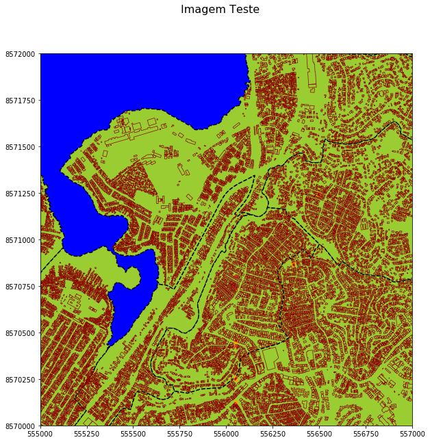

```python
fig, layers = plt.subplots(figsize=(10,10)
                            #,dpi=30
                           )
# pltando a imagem de fundo
recorte.plot(ax = layers, color = 'blue', alpha = 1)
# Plotando os bairros

# layers - quadro o qual poderá ser alterado os valores de xmin, xmax, título e etc

# Plotando os bairros
bairros.plot(ax= layers, color='yellowgreen', edgecolor='black', linestyle="--", lw= 1.5, alpha=1)

# Plotando as edificações com a cor vermelha
edf.plot(ax= layers, color='darkred', lw= 0.7)

try:
    edf_pt.plot(ax= layers, color='orange', lw= 0.7, )
except:
    pass
# titulo da figura
fig.suptitle('Imagem Teste', fontsize=16)

# limites do gráfico
layers.set_xlim(xSC, xSC + deltaX )
layers.set_ylim(ySC,  ySC + deltaY )

#fig.show()
```

## Lendo Arquivos do banco de dados espaciais online Open Street maps

### Através de arquivo baixado manualmente pelo site

```python
gFile = ox.graph_from_file('../OSM/map.osm')
```

```python
gFile
```

```
<networkx.classes.multidigraph.MultiDiGraph at 0x1df6fd9f4e0>
```

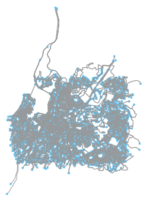

```python
fig, ax = ox.plot_graph(gFile)
plt.tight_layout()
```

### Baixando arquivos por coordenadas limite

O open street maps trabalha com coordenadas WGS84, definidas pelo código epsg 4326. O sistema WGS84 utiliza coordenadas em graus de latitude e longitude.

```python
recorte.bounds
```

|  | minx | miny | maxx | maxy |
| --- | --- | --- | --- | --- |
| 0 | 555000.0 | 8570000.0 | 557000.0 | 8572000.0 |

Para utilizar a mesma geometria limite da utilizada para a importação do Shapefile, é preciso converter o sistema de coordenadas de referência de Sigras 2000 para WGS84.

```python
recorte_LL = recorte.to_crs({'init': 'epsg:4326'})
recorte_LL.bounds
```

|  | minx | miny | maxx | maxy |
| --- | --- | --- | --- | --- |
| 0 | -38.49299 | -12.934936 | -38.474516 | -12.916815 |

O elemento de índice 0 da coluna geometry é um polígono da biblioteca shapely.

```python
 type(recorte_LL.geometry[0])
```

```
shapely.geometry.polygon.Polygon
```

segundo a [documentação do comando ox.graph_from_polygon](https://osmnx.readthedocs.io/en/stable/osmnx.html?highlight=graph_from_place#osmnx.core.graph_from_polygon) ele recebe como priméiro parâmetro um polígono ou multi-polígono da biblioteca citada.

O download do multi-grafo depende da conexão com a internet

```python
gLatLon =  ox.graph_from_polygon(
                                   recorte_LL.geometry[0]
                                 , network_type = 'all_private'
                                 , truncate_by_edge = True
                                 , retain_all = True
                            )
```

```python
gLatLon
```

```
<networkx.classes.multidigraph.MultiDiGraph at 0x1df752f64a8>
```

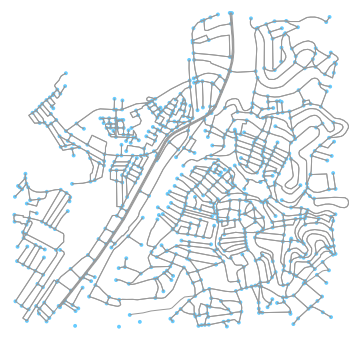

[output not shown]

```python
ox.plot_graph(ox.project_graph(gLatLon))
```

### Através do endereço (geocoding)

```python
gCode = ox.graph_from_place('Salvador, Bahia, Brazil', network_type="drive")
```

O download do multi-grafo depende da conexão com a internet

```python
gCode
```

```
<networkx.classes.multidigraph.MultiDiGraph at 0x1df752e8438>
```

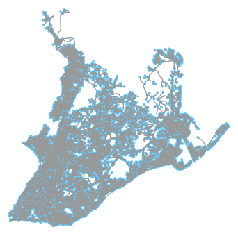

[output not shown]

```python
ox.plot_graph(ox.project_graph(gCode))
```

Centralidade é uma medida da importância de um vértice em um grafo. Os critérios de medida da importância variam. Os quatro mais utilizados são:

```
1. grau
2. intermediação
3. proximidade
4. vetor próprio
```

O código abaixo calcula a centralidade de proximidade da malha viária da localidade gravada no grafo do OSM

### Antenção!

O custo computacional do cálculo da centralidade cresce exponencialmente de acordo com o número de vértices do grafo(a execução do código abaixo pode demorar muitas horas)

```python
# edge closeness centrality: convert graph to line graph so edges become nodes and vice versa
edge_centrality = nx.closeness_centrality(nx.line_graph(gCode))
```

O código abaixo desenha um gráfico mostrando, em escala de cores a varição da medida de centralidade da malha viária.

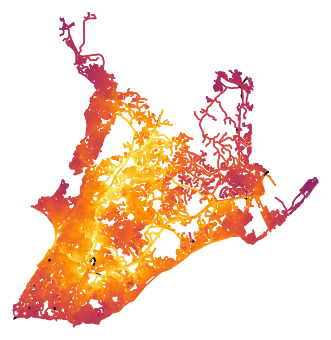

```python
# list of edge values for the orginal graph
ev = [edge_centrality[edge + (0,)] for edge in gCode.edges()]

# color scale converted to list of colors for graph edges
norm = colors.Normalize(vmin=min(ev)*0.8, vmax=max(ev))
cmap = cm.ScalarMappable(norm=norm, cmap=cm.inferno)
ec = [cmap.to_rgba(cl) for cl in ev]

# color the edges in the original graph with closeness centralities in the line graph
fig, ax = ox.plot_graph(gCode, bgcolor=(0.1,0.3,0.0,0.0), axis_off=True, node_size=0,
                        edge_color=ec, edge_linewidth=1.5, edge_alpha=1)
```

## Juntando o arquivo do OSM com o Arquivo SHP

### Trasnformando de Grafo OSM para geopandas Data frame

```python
osm_pontos, osm_linhas = ox.save_load.graph_to_gdfs(gLatLon)
```

```python
osm_linhas.head()
```

|  | bridge | geometry | highway | key | lanes | length | maxspeed | name | oneway | osmid | service | u | v |
| --- | --- | --- | --- | --- | --- | --- | --- | --- | --- | --- | --- | --- | --- |
| 0 | NaN | LINESTRING (-38.4817005 -12.9226106, -38.48173... | footway | 0 | NaN | 5.818 | NaN | NaN | False | 431452585 | NaN | 592377792 | 4306484891 |
| 1 | NaN | LINESTRING (-38.4817005 -12.9226106, -38.48143... | primary | 0 | 2 | 293.516 | 60 | Avenida Afrânio Peixoto | True | 258852462 | NaN | 592377792 | 3944737722 |
| 2 | NaN | LINESTRING (-38.4806693 -12.9168449, -38.48061... | secondary_link | 0 | NaN | 6.314 | NaN | NaN | True | 86577754 | NaN | 592378346 | 4306607916 |
| 3 | NaN | LINESTRING (-38.4806693 -12.9168449, -38.48063... | primary | 0 | 2 | 69.680 | 60 | Avenida Afrânio Peixoto | True | 406250331 | NaN | 592378346 | 592378351 |
| 4 | NaN | LINESTRING (-38.4806036 -12.9174681, -38.48123... | residential | 0 | NaN | 233.994 | NaN | NaN | False | 88627556 | NaN | 592378351 | 1029167862 |

## Sistemas de coordenadas

### trasnformando para o sistema Sigras 2000

```python
# Mudando o sistema de coordenadas de referência

# Para o Shape de Pontos
osm_pontos.to_crs(bairros.crs, inplace = True)
# Para o Shape de Bairros
osm_linhas.to_crs(bairros.crs, inplace = True)
```

Odenando as colunas do shape das linhas

```python
# Ordenando as colunas das linhas para que a coluna de geometria fique por último
osm_linhas_cols = osm_linhas.columns.tolist()
osm_linhas_cols = [x for x in osm_linhas_cols if x != 'geometry']
osm_linhas_cols.append('geometry')
osm_linhas = osm_linhas[osm_linhas_cols]
```

```python
osm_linhas.head()
```

|  | bridge | highway | key | lanes | length | maxspeed | name | oneway | osmid | service | u | v | geometry |
| --- | --- | --- | --- | --- | --- | --- | --- | --- | --- | --- | --- | --- | --- |
| 0 | NaN | footway | 0 | NaN | 5.818 | NaN | NaN | False | 431452585 | NaN | 592377792 | 4306484891 | LINESTRING (556223.3656601022 8571360.65885263... |
| 1 | NaN | primary | 0 | 2 | 293.516 | 60 | Avenida Afrânio Peixoto | True | 258852462 | NaN | 592377792 | 3944737722 | LINESTRING (556223.3656601022 8571360.65885263... |
| 2 | NaN | secondary_link | 0 | NaN | 6.314 | NaN | NaN | True | 86577754 | NaN | 592378346 | 4306607916 | LINESTRING (556336.5217465418 8571998.06138254... |
| 3 | NaN | primary | 0 | 2 | 69.680 | 60 | Avenida Afrânio Peixoto | True | 406250331 | NaN | 592378346 | 592378351 | LINESTRING (556336.5217465418 8571998.06138254... |
| 4 | NaN | residential | 0 | NaN | 233.994 | NaN | NaN | False | 88627556 | NaN | 592378351 | 1029167862 | LINESTRING (556343.5093335714 8571929.12723277... |

```python
osm_pontos.head()
```

|  | highway | osmid | x | y | geometry |
| --- | --- | --- | --- | --- | --- |
| 592377792 | NaN | 592377792 | -38.4817 | -12.9226 | POINT (556223.3656601022 8571360.658852631) |
| 592377803 | NaN | 592377803 | -38.4805 | -12.9169 | POINT (556350.339344732 8571996.562528457) |
| 592378346 | NaN | 592378346 | -38.4807 | -12.9168 | POINT (556336.5217465418 8571998.061382545) |
| 592378351 | NaN | 592378351 | -38.4806 | -12.9175 | POINT (556343.5093335714 8571929.127232777) |
| 592378362 | NaN | 592378362 | -38.4815 | -12.9222 | POINT (556243.6960290928 8571404.168260001) |

### Estatística descritivas do DF osm_linhas

```python
osm_linhas.describe(include='all')
```

|  | bridge | highway | key | lanes | length | maxspeed | name | oneway | service | u | v | geometry |
| --- | --- | --- | --- | --- | --- | --- | --- | --- | --- | --- | --- | --- |
| count | 6 | 2054 | 2054.000000 | 33 | 2054.000000 | 33 | 232 | 2054 | 118 | 2.054000e+03 | 2.054000e+03 | 2054 |
| unique | 1 | 14 | NaN | 1 | NaN | 1 | 27 | 2 | 2 | NaN | NaN | 2054 |
| top | yes | residential | NaN | 2 | NaN | 60 | Rua Padre Antônio Vieira | False | driveway | NaN | NaN | LINESTRING (556536.1844486846 8571385.22782885... |
| freq | 6 | 1713 | NaN | 33 | NaN | 33 | 46 | 2008 | 62 | NaN | NaN | 1 |
| mean | NaN | NaN | 0.006816 | NaN | 74.858000 | NaN | NaN | NaN | NaN | 1.708460e+09 | 1.708382e+09 | NaN |
| std | NaN | NaN | 0.082297 | NaN | 74.955946 | NaN | NaN | NaN | NaN | 1.335574e+09 | 1.335211e+09 | NaN |
| min | NaN | NaN | 0.000000 | NaN | 2.301000 | NaN | NaN | NaN | NaN | 5.923778e+08 | 5.923778e+08 | NaN |
| 25% | NaN | NaN | 0.000000 | NaN | 32.251750 | NaN | NaN | NaN | NaN | 1.005901e+09 | 1.005901e+09 | NaN |
| 50% | NaN | NaN | 0.000000 | NaN | 53.966000 | NaN | NaN | NaN | NaN | 1.005902e+09 | 1.005902e+09 | NaN |
| 75% | NaN | NaN | 0.000000 | NaN | 95.081250 | NaN | NaN | NaN | NaN | 1.583408e+09 | 1.583408e+09 | NaN |
| max | NaN | NaN | 1.000000 | NaN | 1139.594000 | NaN | NaN | NaN | NaN | 5.769358e+09 | 5.769358e+09 | NaN |

```
(8570000, 8572000)
```

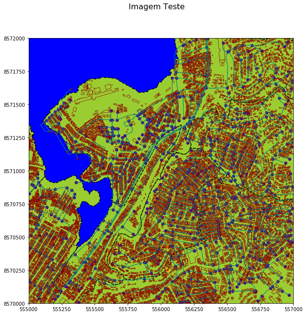

```python
fig2, layers2 = plt.subplots(figsize=(10,10)
                            #,dpi=30
                           )

recorte.plot(ax = layers2, color = 'blue', alpha = 1)
# Plotando os bairros
# Limites preto
# alpha - transparência
# layers - quadro o qual poderá ser alterado os valores de xmin, xmax, título e etc


bairros.plot(ax= layers2, color='yellowgreen', edgecolor='black', linestyle="--", lw= 1.5, alpha=1)

# Plotando as edificações com a cor vermelha
edf.plot(ax= layers2, color='darkred', lw= 0.7)

try:
    edf_pt.plot(ax= layers2, color='orange', lw= 0.7, )
except:
    pass

# importados do OSM
osm_linhas.plot(ax= layers2, color='teal', lw= 0.8, )
osm_pontos.plot(ax= layers2, color='indigo', lw= 0.4, )

# titulo da figura
fig2.suptitle('Imagem Teste', fontsize=16)

# limites do gráfico
layers2.set_xlim(xSC, xSC + deltaX )
layers2.set_ylim(ySC,  ySC + deltaY )
```

```python
osm_linhas.dtypes
```

[output not shown]

Devido a incompatibilidades entre as estruturas de dados do shapefile e do OSM algumas colunas precisam ser tratadas

```python
osm_linhas.oneway = osm_linhas.oneway.astype(int)
osm_linhas.key = osm_linhas.key.astype(int)
osm_linhas.name = osm_linhas.name.astype(str)
osm_linhas.bridge = osm_linhas.bridge.astype(str)
```

```python
osm_select = osm_linhas.filter( items= [ 'name', 'oneway','key','length', 'bridge' ,'geometry' ])
```

```python
osm_select.to_file('./output/teste01.shp', driver='ESRI Shapefile')
```